# The 7 Reasons Most Econometric Investments Fail - `NNS` Contributions Towards Solutions

# Introduction

Marcos Lopez de Prado recently shared a presentation titled, `The 7 Reasons Most Econometric Investments Fail`. It is a wholesale identification on the misuse of traditional statistical methods in quantitative finance.

Please download Marcos’ report here https://ssrn.com/abstract=3373116, or watch a video on the presentation here: https://www.youtube.com/watch?v=BRUlSm4gdQ4.

This quick note is not an argument against any of the points Marcos raises, rather to illustrate how `NNS` and my research with David Nawrocki and Hrishikesh Vinod has been addressing these issues for the last several years. I will use his examples with each of his pitfalls and show how `NNS` provides superior insight to traditional methods.

### Load Required Packages in R `NNS (>= 11.6)`

```r
#require(devtools); install_github('OVVO-Financial/NNS', ref = "NNS-Beta-Version")
require(NNS)
require(plyr)
require(data.table)
```

# Pitfall #1: Structured Data

- `NNS` does not utilize standard transformations in order to achieve stationarity.
- `NNS` is based on a hierarchical and partitional clustering method that is able to preserve the original covariance matrix.
- Unstructured, categorical, and other non-numeric data is seamlessly encoded in `NNS` for analysis.

### `NNS` Clustering

Below is an example of the partitioning method based on partial moment quadrants. Each observation is sequentially labelled per the quadrant it resides in. A useful analogy is that of an observation being a leaf and sequentially labeling the leaf from the trunk of the tree through the successively smaller branches that leaf is located on.

The (lengthy) output shows the `order` of partitioning, the observations and their associated `quadrant` label.

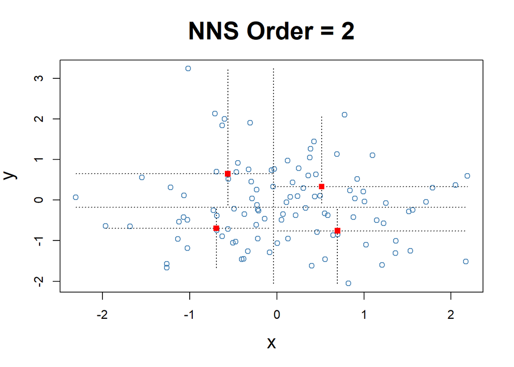

```
## $order
## [1] 2
##
## $dt
##                 x           y quadrant prior.quadrant
##   1: -0.560475647 -0.71040656      q43             q4
##   2: -0.230177489  0.25688371      q23             q2
##   3:  1.558708314 -0.24669188      q31             q3
##   4:  0.070508391 -0.34754260      q32             q3
##   5:  0.129287735 -0.95161857      q34             q3
##   6:  1.715064987 -0.04502772      q13             q1
##   7:  0.460916206 -0.78490447      q34             q3
##   8: -1.265061235 -1.66794194      q44             q4
##   9: -0.686852852 -0.38022652      q41             q4
##  10: -0.445661970  0.91899661      q21             q2
```

[output cut: 98 more lines]

```r
set.seed(123);x=rnorm(100);y=rnorm(100)
NNS.part(x,y,Voronoi=TRUE)
```

### `NNS` Covariance

Next we can show the covariance matrix from the partial moment quadrants:

- Co-upper partial moment CUPM [upper right]
- Co-lower partial moment CLPM [lower left]
- Divergent-lower partial moment DLPM [lower right]
- Divergent-upper partial moment DUPM [upper left]

By adding of the CLPM and CUPM off-diagonals, and subtracting the DLPM and DUPM off-diagonals, we arrive at the covariance of $x,y$.

This is critical as it permits completely different objective functions, rather than just manipulating the entire covariance matrix.

Please see the following for more on partial moments’ role as the elements of variance and links to even more equivalences with traditional measures:

`Elements of Variance` https://www.linkedin.com/pulse/elements-variance-fred-viole/

Here are the individual partial moment matrices, and the aggregate covariance matrix provided by `NNS`.

```r
# Store x,y into Matrix form
A=cbind(x,y)
PM.matrix(LPM_degree = 1, UPM_degree = 1, target = "mean", variable = A, pop_adj = TRUE)
```

```
## $cupm
##           x         y
## x 0.4299250 0.1033601
## y 0.1033601 0.5411626
##
## $dupm
##           x         y
## x 0.0000000 0.1469182
## y 0.1560924 0.0000000
##
## $dlpm
##           x         y
## x 0.0000000 0.1560924
## y 0.1469182 0.0000000
##
## $clpm
##           x         y
## x 0.4033078 0.1559295
## y 0.1559295 0.3939005
##
## $cov.matrix
##             x           y
## x  0.83323283 -0.04372107
## y -0.04372107  0.93506310
```

```r
# Traditional Covariance
cov(A)
```

```
##             x           y
## x  0.83323283 -0.04372107
## y -0.04372107  0.93506310
```

# Pitfall #2: Correlations / Betas

- `NNS` is able to determine non-linear relationships between variables. See the article for a full demonstration on `NNS` correlation and dependence:

`Nonlinear Correlation and Dependence Using NNS` https://ssrn.com/abstract=3010414.

- `NNS` regressions are not dominated by outliers and can accurately determine partial derivatives in the presence of noise. See the following article,

`Nonparametric Regression Using Clusters` http://rdcu.be/tz0J.

Below we recreate the examples Marcos provides and report the `NNS` results for correlation and dependence:

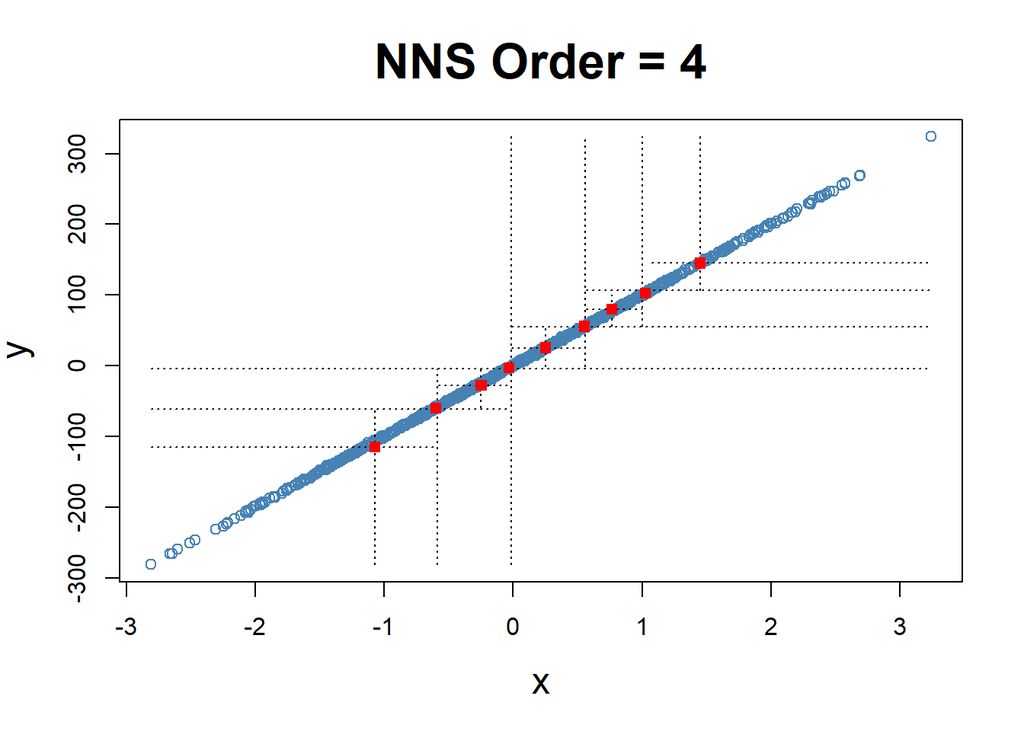

```
## $Correlation
## [1] 0.9877512
##
## $Dependence
## [1] 0.9877512
```

```r
# Generate x,y,e
set.seed(123);x=rnorm(1000);y=rnorm(1000);e=rnorm(1000)
y=100*x+e
NNS.dep(x,y,print.map = TRUE)
```

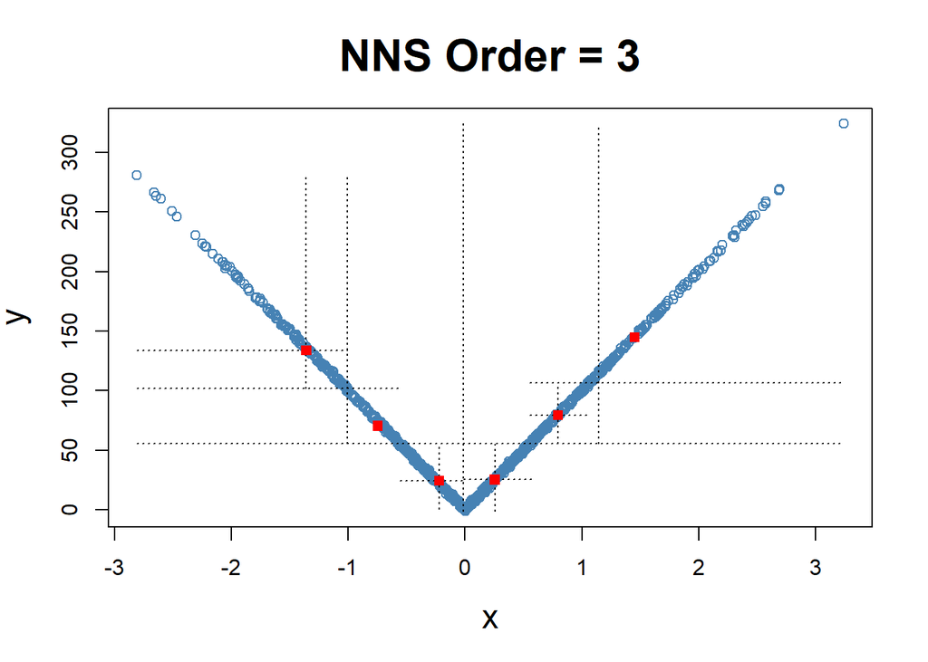

```
## $Correlation
## [1] 0.09562359
##
## $Dependence
## [1] 0.9086349
```

```r
y=100*abs(x)+e
NNS.dep(x,y,print.map = TRUE)
```

# Pitfall #3: Variance Adjudication & The Causality Fallacy

- `NNS` regression is not just interpolation, but very good extrapolation as well. See the previous regression link for more. `Nonparametric Regression Using Clusters`
- Regression is not the wrong tool per se, rather what and how you are regressing is of more importance. See the following forecasting presentation which utilizes `NNS` regressions to achieve excellent forecasting results.

### `NNS` Forecasting Presentation

Download the .pdf file here: https://ssrn.com/abstract=3382300

### `NNS` Forecasting vs. KERAS LSTM Deep Learning

View and download the .html file here: https://htmlpreview.github.io/?https://github.com/OVVO-Financial/NNS/blob/NNS-Beta-Version/examples/Sunspots_example.html

# Pitfall #4: Specification-Interaction Search

- `NNS` can properly consider missing interaction effects as well, since, `NNS` is indeed a machine learning method! The clustering `NNS.part` is the basis for `NNS.reg` . It effectively bridges the supervised and unsupervised leaning branches in the image below.

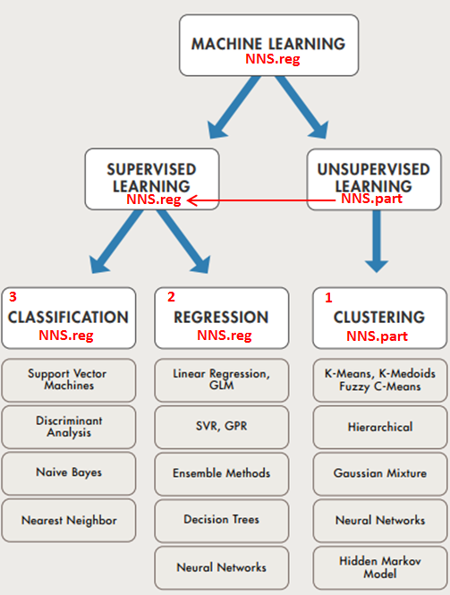

### `NNS` Machine Learning

See the following link for `NNS` comparisons vs. other machine learning methods on classical problem sets:

`Classification Using NNS Clustering Analysis` https://ssrn.com/abstract=2864711

### `NNS` Stack

See the following link for a brief comparison of the `NNS.stack` method (again, all based on the `NNS` clustering and regression methods) vs. other inference methods https://papers.ssrn.com/abstract=3592491

Below is the example Marcos uses for the missing interaction term and correlation between predicted and actual observations using `NNS`.

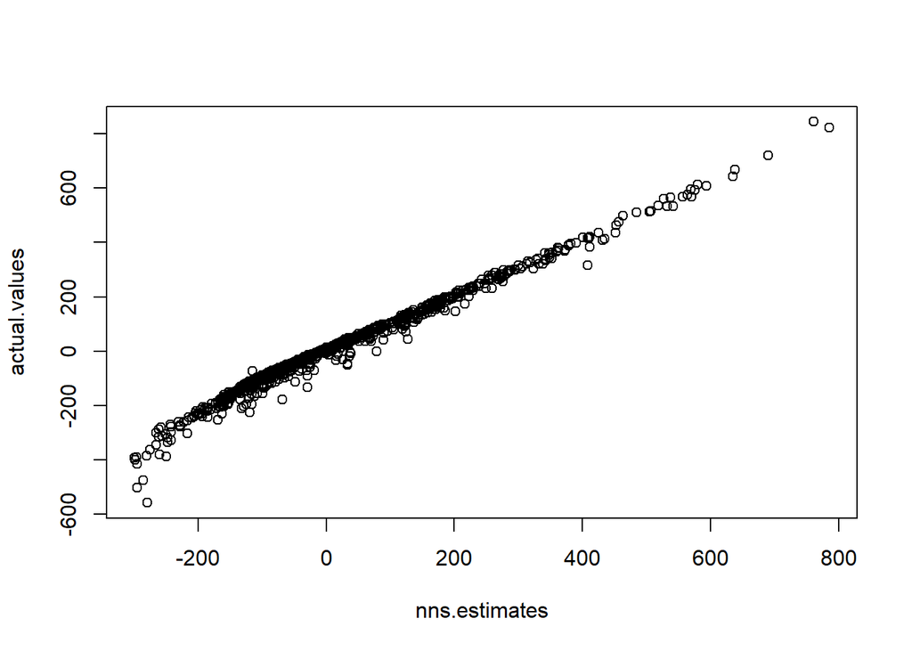

```r
set.seed(123);x_1=rnorm(1000);x_2=rnorm(1000);e=rnorm(1000)

y = 100*x_1 + 100*x_2 + 100*(x_1 * x_2) + e

# Generate new test data
set.seed(321);test.x_1=rnorm(1000);test.x_2=rnorm(1000)

# Store estimates
nns.estimates = NNS.stack(cbind(x_1,x_2), y, IVs.test = cbind(test.x_1,test.x_2))$stack

actual.values = 100*test.x_1 + 100*test.x_2 + 100*(test.x_1 * test.x_2)

plot(nns.estimates,actual.values)
```

```r
cor(nns.estimates,actual.values)
```

```
## [1] 0.9913709
```

# Pitfall #5: p-Values

- We identify a problem with p-values where the power of the test is completely ignored. `NNS` proposes a solution based on degree 1 Lower Partial Moment CDFs.

Below is an image from the paper illustrating a decreasing $\beta$, signifying an increasing power (in blue) and how p-values (in red) jump to significant levels almost immediately!

### `NNS` p-value Paper

The full paper demonstrating this effect is available for download here:

`Continuous CDFs and ANOVA with NNS` https://ssrn.com/abstract=3007373

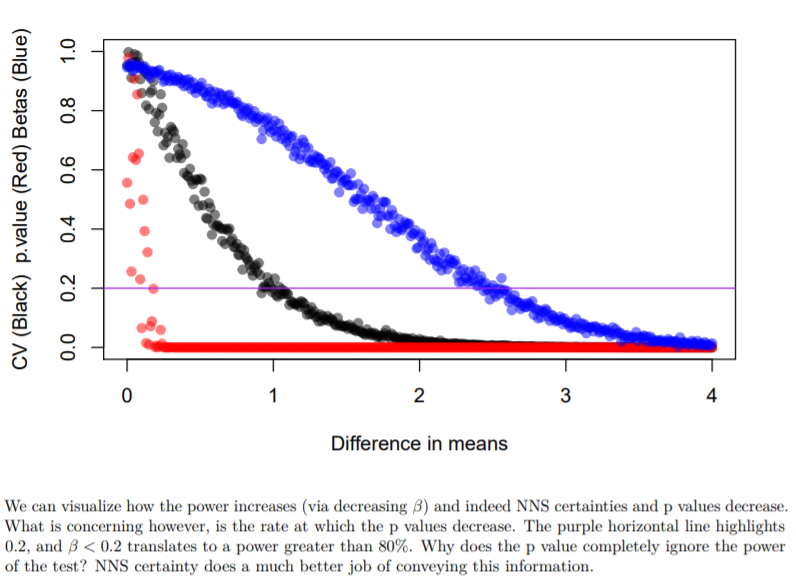

### `NNS` Feature Importance

Below is an example where the `NNS dimension reduction regression` is able to identify the significant regressors from 45 additional nonsensical noisy regressors. `NNS` also contains a routine `NNS.stack` to find the optimal threshold to seperate these regressors.

```r
# Noisy regressor example from: http://www.win-vector.com/blog/2016/05/pcr_part1_xonly/
# build example where even and odd variables are bringing in noisy images
# of two different signals.
mkData <- function(n) {
  for(group in 1:10) {
    # y is the sum of two effects yA and yB
    yA <- rnorm(n)
    yB <- rnorm(n)
    if(group==1) {
      d <- data.frame(y=yA+yB+rnorm(n))
      code <- 'x'
    } else {
      code <- paste0('noise',group-1)
    }
    yS <- list(yA,yB)
    # these variables are correlated with y in group 1,
    # but only to each other (and not y) in other groups
    for(i in 1:5) {
      vi <- yS[[1+(i%%2)]] + rnorm(nrow(d))
      d[[paste(code,formatC(i,width=2,flag=0),sep='.')]] <- ncol(d)*vi
    }
  }
  d
}

set.seed(12345)
dTrain <- mkData(1000)
dTest <- mkData(1000)

# Find optimal threshold and store output
optimal.threshold = NNS.stack(dTrain[,-1], dTrain[,1], method = 2,
                              dim.red.method = "cor")$NNS.dim.red.threshold
optimal.threshold
```

```
## [1] 0.36
```

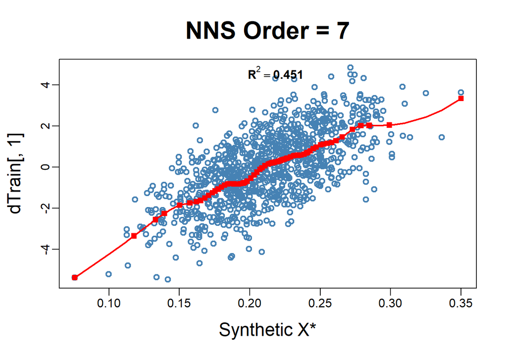

```
##        Variable Coefficient
##  1:        x.01   0.4064923
##  2:        x.02   0.3623050
##  3:        x.03   0.4342246
##  4:        x.04   0.3943531
##  5:        x.05   0.4009567
##  6:   noise1.01   0.0000000
##  7:   noise1.02   0.0000000
##  8:   noise1.03   0.0000000
##  9:   noise1.04   0.0000000
## 10:   noise1.05   0.0000000
## 11:   noise2.01   0.0000000
## 12:   noise2.02   0.0000000
## 13:   noise2.03   0.0000000
## 14:   noise2.04   0.0000000
```

[output cut: 38 more lines]

```r
# Print synthetic regressor equation using 'optimal.threshold'
print( NNS.reg(dTrain[,-1], dTrain[,1],  dim.red.method = "cor" ,
               threshold = optimal.threshold, plot = TRUE, smooth = TRUE)$equation )
```

# Pitfall #6: Training-Set Overfitting

- `NNS` has the ability to perfectly fit any training set. However, the ability to accurately determine signal:noise ratios allows `NNS` to avoid overfitting. The regression paper `Nonparametric Regression Using Clusters` link from pitfall #2 thoroughly discusses and proves this avoidance of overfitting.

# Pitfall #7: Test-Set Overfitting

- The use of EXPECTED partial moments goes a long way in addressing this issue in finance. We published `a` not `the` way to accomplish this and underlying rationale borrowed from information theory. Please see the following link for more on the method and link to the paper:

`Expected Partial Moments` https://www.linkedin.com/pulse/expected-partial-moments-fred-viole/

# Summary

`NNS` is a quite capable methodology able to properly address many of these pressing issues Marcos so diligently raises.

I look forward to further discussions and collaboration with those equally as passionate about these issues, and open to embracing alternative solutions. If you found this presentation interesting or useful, please feel free to reach out via e-mail: ovvo.financial.systems@gmail.com

Thanks for your interest!